[interactive chart not shown]

ARCHITECTURE DEEP REPORT · 2026-09-12 · REPO SNAPSHOT ED93CD2 · V0.7.0

# 从图纸到证据： CAD2GIS 的架构突破

An Evidence-First, Replayable DWG→GIS Architecture

CAD→GIS 转换四十年没有解决的不是“读文件”，而是可信度。CAD2GIS 用 48 天、91 次提交给出了一条反常规的路：把 AI 关进控制平面，把几何交给确定性代码，把每一个数字绑上证据。

数据基准：GitHub 仓库 Mola-maker/CAD2GIS 本地快照 commit ed93cd2（2026-09-12 · v0.7.0）· 五天 39 提交 +48,294 行（K19）· 证据分级：仓库一手 > 官方/学术交叉验证 > 检索结论

SCROLL

§0 · 执行摘要

## 不是又一个转换器，而是一条可审计的证据生产线

它不承诺厘米级精度，它承诺每一个精度声明都能被独立复核。

CAD→GIS 转换四十年没有解决的不是“读文件”，而是**可信度**：图纸没有坐标权威、块嵌套无人展开、标注与几何两张皮、转换规则针对单图硬编码、结果无法重放。CAD2GIS 用 48 天、91 次提交（K18/K19）给出了一条反常规的路：*把 AI 关进控制平面，把几何交给确定性代码，把每一个数字绑上证据*。

67,545 行生产代码、50 个 MCP 工具、0.7.0 冻结终测 1,300 项通过 / 0 failures（K20/K21），支撑 10 张真实电信图纸（4 张开发基线 + 6 张留出验证集）全部完成 source-bound 转换，九图 152,621 条 reader records 全部入库（K31），139/139 条缆段长度闭合、最大长度对账残差 1.24×10⁻⁸ m（K9/K10）。全部交付保持 `CONDITIONAL / not independently verified`，直到测量级控制点出现（K10/K11）。

§1 · 行业 GAP

## 四十年没填平的六个坑

DWG 读得出、坐标没人管、块展不开、规则不可复用——每条路都断在同一处：可信度。

DWG 是 Autodesk 私有二进制格式，40 多年演进超 30 个版本；GIS 世界至今没有一条“合法、免费、完整”的读取路径——GDAL 的 DWG 驱动依赖 ODA 商业库，官方发行版一律不含；内置 libopencad 只读且版本有限；GNU LibreDWG 纯逆向、GPLv3、官方状态仍是 beta，写支持止步 r2004（K2/K3/K4）。GDAL 官方文档写着一句行业判词：**“DWG files are considered to have no georeferencing information through OGR”**——读出来的坐标是裸绘图坐标，坐标权威问题整个推给用户（K2）。

既有方案的断点都有官方出处。Esri 官方配准 CAD 只能把控制点存进附属 `.wld` world file，仅限 1–2 个控制点的相似变换，纠不了畸变（K5）；导入块属性要求预做 seed file，TAG 名必须与 GIS 字段名**逐字一致**（K6）。FME 官方承认“转换会丢标注和符号信息”是本质问题：CAD 是“图形+标注”范式，GIS 是“要素+属性”范式（K3）。学术框架（MDPI C2G, 2022）证实：文字压线造成缝隙、连续线不闭合成面、注记要人工“就近挂接”、几何误差破坏配准（K15）。

2024–2026 年的 LLM-for-GIS 主流（LLM-Geo、GIS Copilot、MapGPT）都是让 LLM 编排确定性工具；清华 FIB-Lab 的 GeoHaluBench（EMNLP 2025 Findings）实证 20 个 LLM 系统普遍产生地理空间幻觉——假 POI、错地址、不存在的路（K16/K17）。*让一个会幻觉坐标系的系统去写坐标，是 2026 年 GIS 领域最危险的新坑。*

**血缘空白地带。**ISO 19115 与 W3C PROV-O 标准成熟、OpenLineage/DataHub 等通用工具成熟，但“CAD→GIS 转换级血缘”（哪条 GIS 要素来自哪个 DWG 块/图层/规则）未检索到成熟方案——此为检索结论而非存在性断言（K17b）。

§2 · 架构

## 一条 12 节点的证据生产线

几何在数据平面里被确定性代码一步步推向交付；AI 只在控制平面里读证据、下决策。

canonical pipeline 按 K4b 原文转录：从 source bundle 到独立的 revisioned 审查工作区，每个环节要么是不可变事实的落盘，要么是一道显式门禁。实际代码阶段链（StageRecorder，K7）共 9 个 stage contract 回执——`ingest → plan_domain → semantic_classification → topology → semantic_revision_projection → write_evidence_graph → write_source_gpkg → write_evidence_gpkg → write_delivery_gpkg`——全部 `cacheable: false`，**禁止结果缓存复用**（K1）。

0.7.0 起，semantic mapping 之后默认接两步：**OSM 标准匹配**（`--matching osm`，四态 matched / coarse / unavailable / abstained，K25）与 **SVG 候选提取**（`svg_mode=candidate`，失败不发布新 run，K27）。配准阶梯不变。交付侧只有一个决策：**“单一转换核心，薄入口，按平台封装”**（K27 原文）——同一核心被封装为 Windows/Linux 桌面入口、Android HTTPS 客户端与 MCP 智能体。

§3 · 设计哲学

## 九大架构突破

九条相互咬合的架构决策，每一条都反行业惯例，每一条都有数字兜底。

> It may not invent coordinates, lengths, zone polygons, or entities; approve its own transform; or bypass independent check-point gates.

> — **LLM_AGENT_ARCHITECTURE.md**, CAD2GIS 仓库（K4b）

> 背景AI 权力法案的原文条款：LLM 是规划器与语义推理者，坐标、曲线、长度、变换参数全部由确定性代码计算。 为何重要对照 GeoHaluBench 对 20 个 LLM 系统地理幻觉的实证（K16），这不是保守，是唯一正确的分工。

> The same source, profiles, code fingerprint, runtime fingerprint, and Decision Pack must be replayable without contacting a model provider.

> — **LLM_AGENT_ARCHITECTURE.md**, CAD2GIS 仓库（K4b）

> 背景重放边界条款：同一份源、同一套规则、同一个代码与运行时指纹，必须在不接触任何模型提供商的情况下字节级重放。 为何重要这把“AI 参与”从不可复现的黑箱变成可审计的流水线工序。

> Equivalence is a regression check, not surveyed accuracy proof.

> — **SOURCE_REPLAY_SEMANTIC_DELIVERY_2026-09-06.md**, CAD2GIS 仓库（K13）

> 背景交付等价比较精确到几何 BLOB、长度与 lineage，但项目明确拒绝把“两次运行一致”包装成“实测精度”。 为何重要精度诚实是卖点不是弱点——这是全报告的裁决基调。

§4 · 证据

## 数字不说谎

7 轮回归、6 张留出图纸、11 份交付单元、139 条闭合缆段——每个数字都可以点进去看依据。

§4.5 · 五日三级

## 五天，三个版本，能力翻了一翻；精度声明，一个字没变

0.4.0 → 0.6.0 → 0.7.0 → 平台验收：39 次提交、318 个文件、+48,294 行（K19）；CONDITIONAL 封顶、Manado BLOCKED、Android E2E blocked，一项没松。

2026-09-08 到 2026-09-12 的五天里，仓库从 0.4.0 基线连跳三级：0.6.0 升级精度与证据链（695 passed，K24），0.7.0 冻结语义与全平台交付（1,312 tests：1,300 passed / 0 failures / 306.237 s，K21），最后一天四类平台制品同日构建验收（K23）。OSM 标准匹配成为默认路径，GCP 微调搬上工作台，LibreDWG 原生缺陷被打上游补丁。

但有两处**故意没有动**：**Manado 保留 `BLOCKED_STALE_INVENTORY_BINDING`**——清单绑定与新事实不匹配，阻断保留，不得以旧批准套新事实（K31）；**Android 端到端仍然 blocked**——没有系统信任的 HTTPS 服务端，就不宣称端到端可用（K23）。软件行为证据 ≠ 测量级精度：本节所有 OSM 与平台新数字都只描述软件行为，精度声明一个字没变。

§5 · 裁决

## 钉在标尺最右端

从“营销话术”到“可独立复核的工程声明”——CAD2GIS 钉在最右端，并且自己把够不到的地方划了线。

### 它证明了

在 10 张真实电信 APD 图纸上，一条 source-bound、证据优先、AI 只居控制平面的流水线可以端到端跑通，且每个数字可回溯到内容寻址证据（K8/K9/K10）。

### 它没有证明（也拒绝假装证明）

绝对地面精度——无测量级 GCP，全部交付 `CONDITIONAL / not independently verified`。原文：**“Passing source geometry/topology/length gates does not authorize an absolute map-accuracy claim”**（K10）。

### 0.7.0 的边界声明原样保留

能力翻倍，声明不变——这是本次升级的裁决支柱：全部 run 仍 `CONDITIONAL`、`authority=relative_osm`、`absolute_accuracy_verified=false`（K21/K31）；**Android 端到端仍 blocked**（无系统信任的 HTTPS 服务端，K23）；**Windows 安装器未签名**（K23）；Manado 的阻断保留不解除（K31）。

### 最接近的历史类比

最接近的历史类比是 FME 之于 ETL——但 FME 解决“搬数据”，CAD2GIS 解决“为每个被搬的数字立证据”。*这个周期没有真正的先例*：把内容寻址证据图谱 + AI 权限法案 + 精度分级诚实同时作为一等架构约束的系统，在 CAD→GIS 领域未检索到先例（K17b，措辞为“未检索到”）。

文档中心 · DOCUMENTATION CENTER

## 报告讲架构为什么对，手册讲明天怎么用起来

与主报告同目录发布（docs/）：一份十一章分页使用手册 + 四个过程子页——命令逐字转录自仓库文档，素材全部来自真实交付。入口已上移至页面顶部导航。

> “把 AI 关进控制平面，把几何交给确定性代码，把每一个数字绑上证据。”

> —— CAD2GIS 架构三原则 · 文档中心把它落成十一章可执行手册

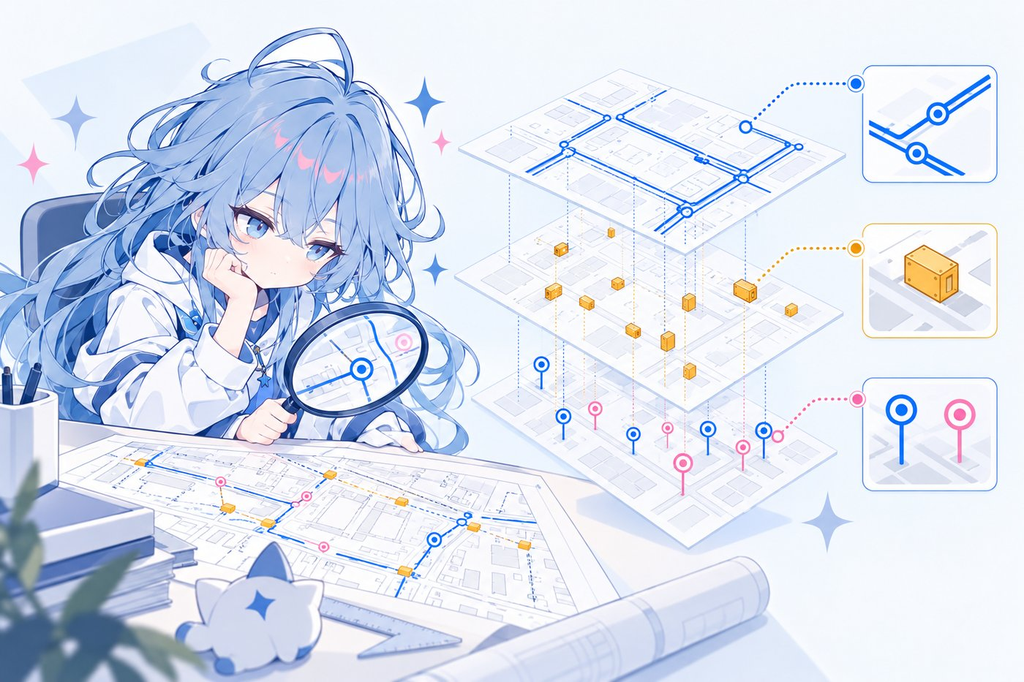

[figure not shown]

从图纸到 GIS 图层再到证据链 · 文档中心视觉 · OC 形象 · molamaker

从 使用手册 · 第一章 安装与首个转换 → 开始，或用顶部导航直达任一子页。

CAD2GIS 文档中心 · 命令逐字转录自仓库文档（usage-docs-material）

附录